# Projet_Actuariat

Travail réalisé par :  
- Skouri Youssef  
- Gharbi Wiem

référence qui nous a été utile:  
https://cran.r-project.org/web/packages/ChainLadder/vignettes/ChainLadder.pdf

## Librairies supplémentaires

Pour la première partie du projet on va se servir de la librairie “ChainLadder” qui facilitera beaucoup le travail à réaliser.

```r
library(ChainLadder)
library(MASS)
```

# Importation des triangles (Question 1)

## Triangle d’ouvertures

```r
tri_ouv=read.csv("C:/Users/Youssef/Documents/Actuariat non vie/Docs Projet/tri_ouvertures.csv",sep = ";")
rownames(tri_ouv)=tri_ouv[,1]
colnames(tri_ouv)=c(tri_ouv[1,1:dim(tri_ouv)[2]])
tri_ouv=as.matrix(tri_ouv[-1,-1])
n=dim(tri_ouv)[1]
#affectation des NA
for (i in 2:n){
  for(j in n:(n-i+2)){
    tri_ouv[i,j]=NA
  }
}
tri_ouv=as.triangle(tri_ouv)#rendre la matrice de type "triangle" du package ChainLadder.
class(tri_ouv)
```

```
## [1] "triangle" "matrix"
```

```r
tri_ouv
```

```
##       dev
## origin     1    2   3  4  5  6  7  8  9 10
##   2005 31116 1976 188 64 12  4  0  2  0  0
##   2006 31198 1922 126 36 12  4  0  0  0 NA
##   2007 35850 1910 132 56 12 10  4  2 NA NA
##   2008 37860 2004 140 62  8  4  4 NA NA NA
##   2009 31142 1970 178 62  6  4 NA NA NA NA
##   2010 32930 1794 184 40 16 NA NA NA NA NA
##   2011 36808 1830 186 84 NA NA NA NA NA NA
##   2012 37568 2222 166 NA NA NA NA NA NA NA
##   2013 37966 2434  NA NA NA NA NA NA NA NA
##   2014 36480   NA  NA NA NA NA NA NA NA NA
```

- On peut remarquer que la grande majorité des dossiers des sinistres sont ouverts durant la même année de survenance.  
- On voit qu’il y a quand même des dossiers qui ne seront ouverts qu’après plusieurs années de l’année de suvenance.

## Triangle des règlements

```r
tri_reg=read.csv("C:/Users/Youssef/Documents/Actuariat non vie/Docs Projet/tri_reglements.csv",sep = ";")

#on a un problèmes des nombre en milliers qui contiennet des espaces, donc ils seront automatiquement transformés en chaînes de caractères.
tri_reg=suppressWarnings(sapply(tri_reg, function(v) {as.numeric(gsub(" ","", as.character(v)))}))

rownames(tri_reg)=tri_reg[,1]
colnames(tri_reg)=c(tri_reg[1,1:dim(tri_reg)[2]])

tri_reg=as.matrix(tri_reg[-1,-1])
for (i in 2:n){
  for(j in n:(n-i+2)){
    tri_reg[i,j]=NA
  }
}
#rendre la matrice triangulaire
tri_reg=as.triangle(tri_reg)
tri_reg
```

```
##       dev
## origin       1       2       3      4      5      6     7      8    9    10
##   2005  932885 3237223 1008634 716841 205622  41787 58214 138219 1147 18654
##   2006  754417 2712185 1848256 450603 164202 129627 32327  57643 7405    NA
##   2007  978419 4125539 1674789 468187 218024 118069 26835  86844   NA    NA
##   2008 1316441 4705346 1533871 497570 274215 122453 47205     NA   NA    NA
##   2009 1515114 5722639 1385629 574877 198014 124870    NA     NA   NA    NA
##   2010 2228111 6243327 1568645 537665 206953     NA    NA     NA   NA    NA
##   2011 2444956 7701845 2268650 466767     NA     NA    NA     NA   NA    NA
##   2012 2270648 9688556 2385764     NA     NA     NA    NA     NA   NA    NA
##   2013 2591382 9200602      NA     NA     NA     NA    NA     NA   NA    NA
##   2014 2045751      NA      NA     NA     NA     NA    NA     NA   NA    NA
```

- Contrairement au triangle d’ouvertures, les règlements des sinistres sont elevés surtout dans l’année qui suit l’année de survenance et décroient plus on avance dans les années.

## Triangle des provisions sinistres à payer (PSAP)

```r
tri_psap=read.csv("C:/Users/Youssef/Documents/Actuariat non vie/Docs Projet/tri_PSAP.csv",sep = ";")

tri_psap=suppressWarnings(sapply(tri_psap, function(v) {as.numeric(gsub(" ","", as.character(v)))}))

rownames(tri_psap)=tri_psap[,1]
colnames(tri_psap)=c(tri_psap[1,1:dim(tri_psap)[2]])

tri_psap=as.matrix(tri_psap[-1,-1])

for (i in 2:n){
  for(j in n:(n-i+2)){
    tri_psap[i,j]=NA
  }
}

tri_psap=as.triangle(tri_psap)
tri_psap
```

```
##       dev
## origin        1        2       3       4       5       6       7       8      9
##   2005  8574694  5339292 4471094 2301412 1227604 1108434 1020606  803918 786420
##   2006  9280800  5511276 3851960 1290482 1030644  820088  696348  757550 671606
##   2007 10669986  6885474 4534658 2144260 2014700 1754708 1613168 1019588     NA
##   2008 11656966  6570890 4869326 2648448 2028432 1883582 1842600      NA     NA
##   2009 12164094  8025886 6056144 3559054 2862232 2506160      NA      NA     NA
##   2010 14152736  8644018 6476866 2696482 2500376      NA      NA      NA     NA
##   2011 16035820  9279056 5531240 2436836      NA      NA      NA      NA     NA
##   2012 20074958 10740326 7721440      NA      NA      NA      NA      NA     NA
##   2013 21839442 11566378      NA      NA      NA      NA      NA      NA     NA
##   2014 21633786       NA      NA      NA      NA      NA      NA      NA     NA
##       dev
## origin     10
##   2005 702514
##   2006     NA
##   2007     NA
##   2008     NA
##   2009     NA
##   2010     NA
##   2011     NA
##   2012     NA
##   2013     NA
##   2014     NA
```

- Comme on remarque, la valeur des provisions sinistres est proportionnelle au nombre de sinistres non réglés, donc en avançant dans les années plus de sinistes sont réglés et par conséquence la valeur des provisions doit diminué avec.

# Analyse des triangles (Question 2 et 3)

## Triangle d’ouvertures

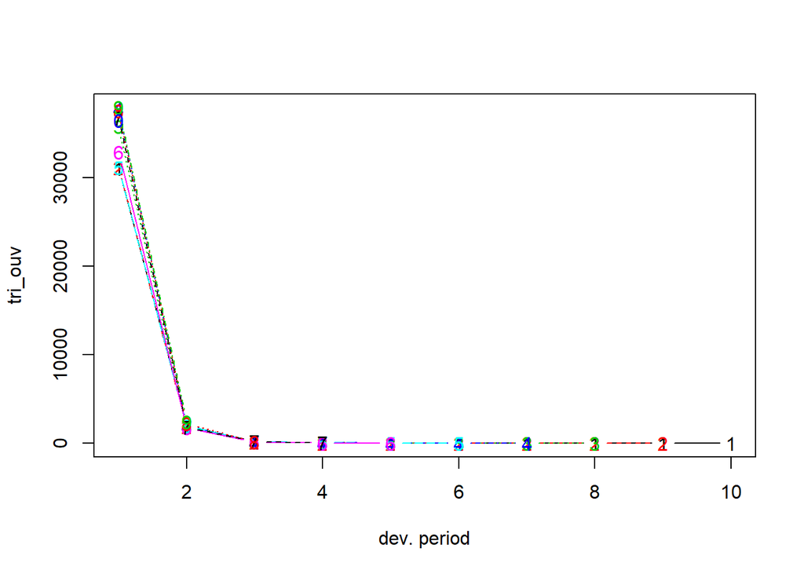

```r
plot(tri_ouv)
```

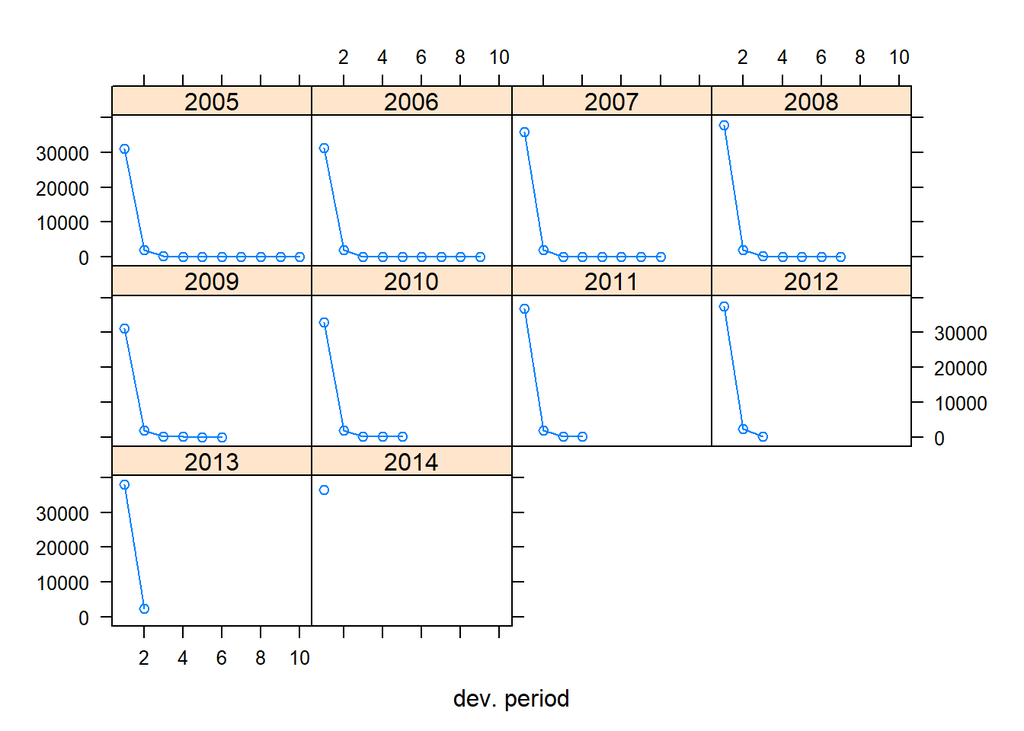

```r
plot(tri_ouv,lattice=TRUE)
```

- Confirme l’analyse du triangle faite en dessus: forte décroissance après la première année (année de survenance)

## Triangle des règlements

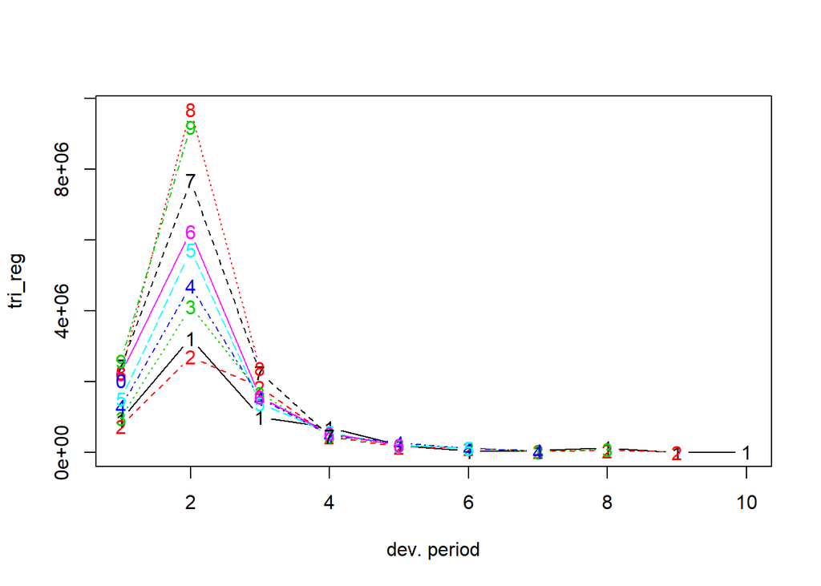

```r
plot(tri_reg)
```

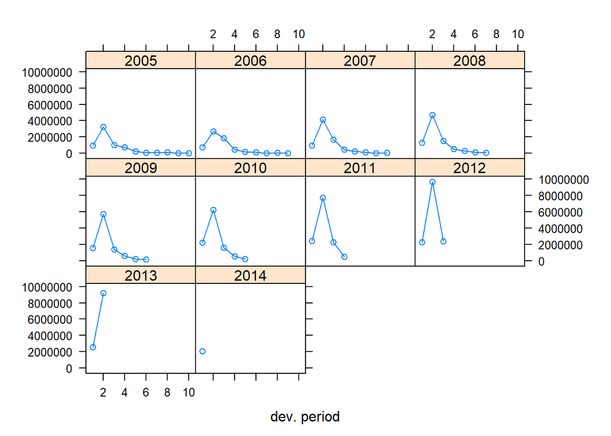

```r
plot(tri_reg,lattice=TRUE)
```

- la somme des règlements atteint son sommet à l’année qui suit l’année de survenance,même si ceci est plus évident pour certaines années plus que d’autres, celà reste toujours vrai.

## Triangle des provisions sinsitres à payer

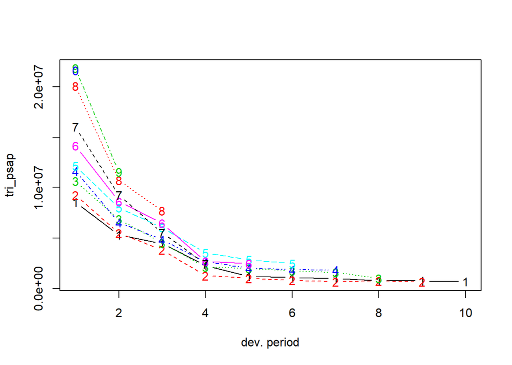

```r
plot(tri_psap)
```

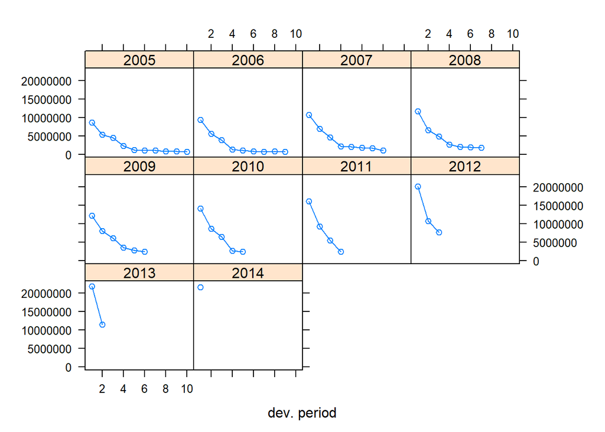

```r
plot(tri_psap,lattice=TRUE)
```

- Même remarque l’éstimation des provisions à payer décroît au cours du temps (plus de sinistres réglés plus l’éstimation des provisions diminue ce qui est logique).